# INTERVIEW PRESENTATION

David

2019-01-02

# WHY BRANDFOLDER?

## BRANDFOLDER CHECKS ALL THE BOXES

- business model = subscription
- technology = SaaS
- total addressable market = anyone with a brand
- provides distinct solution to meaningful problem
  - “*they come for asset management; they stay for the analytics*”
- strong growth with very little churn

# MARKETING

## PERSON SCORING

- in Salesforce, Leads & Contacts are *people*
  - Leads are people you probably want to know
  - Contacts are people you actually know
- who are these people? what is their role?
- what have they done? what have they responded to?

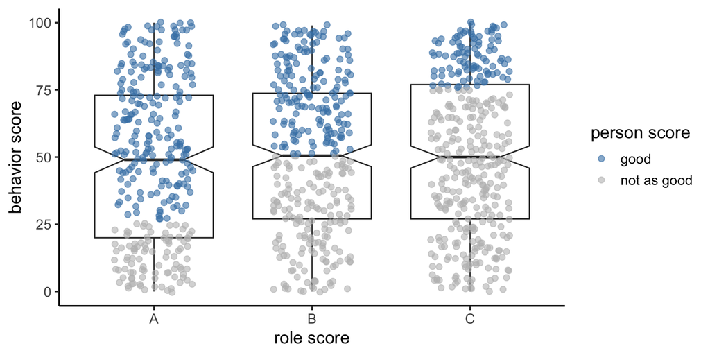

## ACCOUNT SCORING

- combine people scores with account attributes
- can grade accounts by industry, size, technology, age
  - grouped into A, B, and C grades below

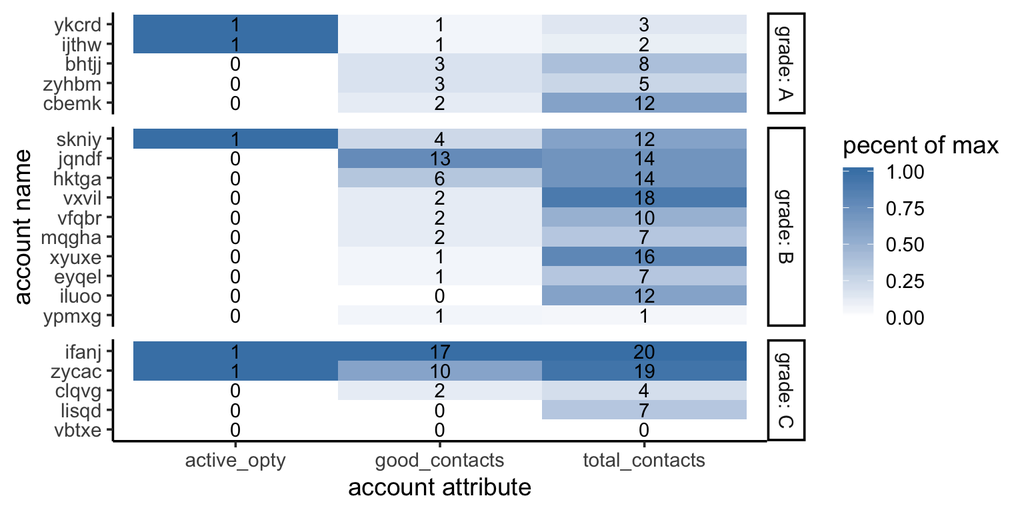

## WHICH EVENTS TO INVEST IN?

- each event requires an investment
- each event should yield a return
  - brand awareness
  - lead acquisition
  - nurture

## EVALUATING EVENTS

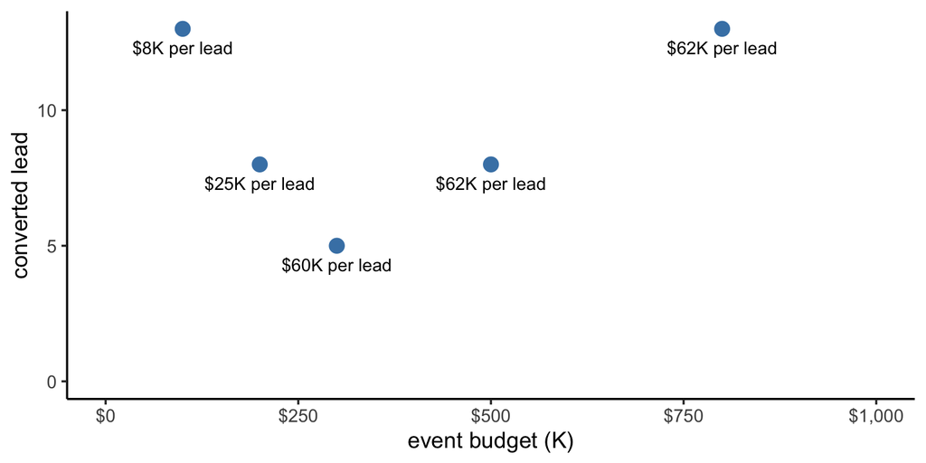

## OPTIMIZING MARKETING INVESTMENTS

- mind the lag
  - today’s investments may not yield bookings for months, years
- decide if `OpportunityContactRole` is important or not
  - this decision and data drives attribution
- milestones to measure
  - how did we acquire the person record?
  - what was first thing they responded to?
  - what did they respond to before the deal created?
  - what did they respond to after deal created but before won?

## INTERPRETTING THE JOURNEY REQUIRES ROBUST PROCESSES

- what if only Hans appeared in `OpportunityContactRole`?
- what if John was organic but Has result of paid media?

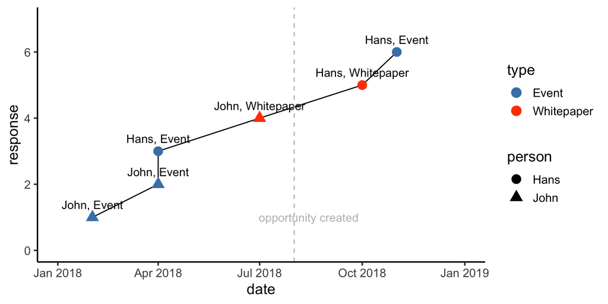

## YOU MAY THINK YOUR FUNNEL IS THIS

[interactive chart not shown]

## BUT REALLY IT LOOKS LIKE

[interactive chart not shown]

# SALES

## TERRITORY AND SEGMENTATION PITFALLS

- segmentation based on attributes that are not locked down
  - industry
  - employees
  - “top account” designations
- taxonomies that do *not* account for account families

## ACCOUNT FAMILIES REQUIRE DECISIONS

- this is where things often go wrong
- what are rules of engagement?
  - does ownership happen at family (parent)? each node?
  - if each node, does ownership go up or down tree?
- will tree impact calculation of land, retain, and expand?

[interactive chart not shown]

## LAND, RETAIN, AND EXPAND

- requires a “flywheel” data set of subscription line items
  - account, product, arr, start date, end date
- find attributes associated with churn risk: size? industry? usage?
- timing and kind of expansion: adding seats or products?

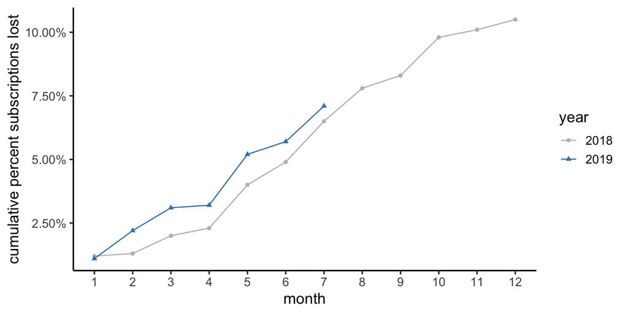

## ALTERNATIVE ACCOUNT GROUPINGS

- group by whitespace and utilization
  - retaining vs. expanding
- engagement
  - active vs. inactive
- part of family vs. stand-alone

## PIE CHARTS

- rank segments most to least
- where would error bars go?
- which grew the most?

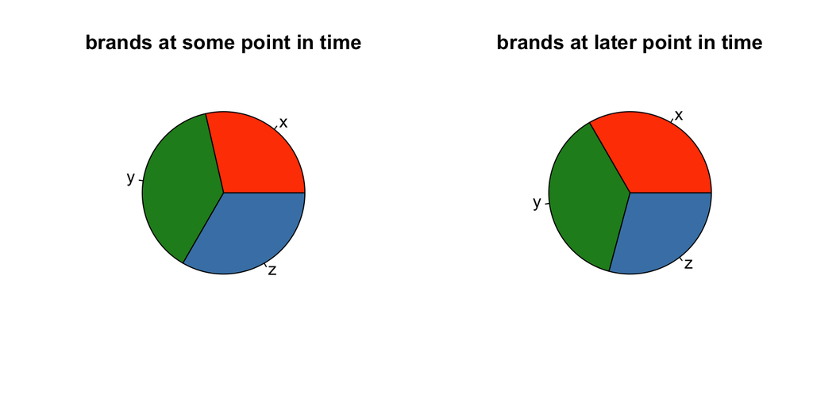

## SAME DATA AS BEFORE

- rank segments most to least
- where would error bars go?
- how are these trending?

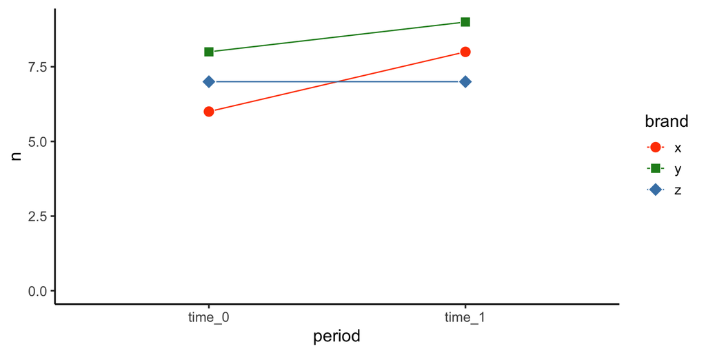

# WRAPPING UP

## WHEN NOT DOING STUFF LIKE THIS

- family of 4 that likes to hike and camp
- run and bike
- do stuff like this
  - tried out `revealjs` markdown for this presentation